# Homework 7

Alan Vongsavanh

2026-01-28

## Instructions

Answer the following questions and/or complete the exercises in RMarkdown. Please embed all of your code and push the final work to your repository. Your report should be organized, clean, and run free from errors. Remember, you must remove the `#` for any included code chunks to run.

## Load the tidyverse

```r
library("tidyverse")
library("janitor")
```

## Data

For this assignment, we will use data from a study on elephants and the effects of poaching on tusk size.

Reference: [Chiyo, Patrick I., Vincent Obanda, and David K. Korir. “Illegal tusk harvest and the decline of tusk size in the African elephant.” Ecology and Evolution 5, 22: 5216–5229 (2015)](https://doi.org/10.1002/ece3.1769). Data deposited at [Dryad Digital Repository](https://doi.org/10.5061/dryad.h6t7j).

**1. Before starting data analysis, read the abstract of the paper to get an idea of the questions being asked. In 2-3 sentences, describe what the study is testing and the variables involved.**  
The study interest of the paper was looking ito whether severe historical elepahnt harvests eliminated large tuskers among survivors and whether elephants born thereafter had smaller tusks.

The paper looks into the tusk size of elephants sampled in different time periods, and also categorized the elephants by sex, age, tusk circumference, and length.

**2. Load `elephants.csv` and store it as a new object called `elephants`.**

```r
elephants <- read.csv("data/elephants.csv")
```

**3. Clean the data by converting variable names to lowercase with no spaces or special characters.**

```r
elephants <- elephants %>%
  clean_names() %>%
  mutate(across(where(is.character),tolower))
```

**4. Use one or more of the summary functions you have learned to get an idea of the structure of the data.**

```r
glimpse(elephants)
```

```
## Rows: 777
## Columns: 7
## $ years_of_sample_collection <chr> "1966-68", "1966-68", "1966-68", "1966-68",…
## $ elephant_id                <chr> "12", "34", "162", "292", "11", "152", "264…
## $ sex                        <chr> "f", "f", "f", "f", "f", "f", "f", "f", "f"…
## $ estimated_age_years        <dbl> 0.080, 0.080, 0.083, 0.083, 0.250, 0.250, 0…
## $ shoulder_height_in_cm      <dbl> 102, 89, 89, 92, 133, 100, 93, 108, 108, 12…
## $ tusk_length_in_cm          <dbl> NA, NA, NA, NA, NA, NA, NA, NA, NA, NA, NA,…
## $ tusk_circumference_in_cm   <dbl> NA, NA, NA, NA, NA, NA, NA, NA, NA, NA, NA,…
```

```r
summary(elephants)
```

```
##  years_of_sample_collection elephant_id            sex
##  Length:777                 Length:777         Length:777
##  Class :character           Class :character   Class :character
##  Mode  :character           Mode  :character   Mode  :character
##
##
##
##
##  estimated_age_years shoulder_height_in_cm tusk_length_in_cm
##  Min.   : 0.08       Min.   : 89.0         Min.   : 22.50
##  1st Qu.: 4.50       1st Qu.:177.0         1st Qu.: 60.95
##  Median :12.00       Median :220.0         Median : 88.00
##  Mean   :15.05       Mean   :210.2         Mean   : 91.59
##  3rd Qu.:23.00       3rd Qu.:244.0         3rd Qu.:116.75
##  Max.   :55.00       Max.   :340.0         Max.   :234.00
##  NA's   :3           NA's   :1             NA's   :180
##  tusk_circumference_in_cm
##  Min.   : 8.00
##  1st Qu.:16.00
##  Median :20.00
##  Mean   :21.01
##  3rd Qu.:25.00
##  Max.   :48.00
##  NA's   :163
```

**5. Use `mutate()` Change the variables `years_of_sample_collection`, `elephant_id`, and `sex` to factors. Be sure to store the output as a new dataframe and use it for the remaining questions.**

```r
elephants <- elephants%>%
  mutate(across(c(years_of_sample_collection, elephant_id, sex), as.factor))
```

**6. From which years were data collected? Show the sample periods below.**

```r
elephants %>%
  select(years_of_sample_collection) %>%
  count(years_of_sample_collection)
```

```
##   years_of_sample_collection   n
## 1                    1966-68 605
## 2                    2005-13 172
```

**7. How many males and females were sampled in this study?**

```r
elephants %>%
  select(sex) %>%
  count(sex)
```

```
##   sex   n
## 1   f 416
## 2   m 361
```

**8. What is the mean, median, and standard deviation for age of males and females included in the study? Separate the results by year of sample collection. Does the sampling look even between years and sexes?**

```r
elephants %>%
  filter(years_of_sample_collection == "1966-68",
         sex == "m") %>%
  summarize(mean_age_m = mean(estimated_age_years, na.rm = T),
            min_age_m = min(estimated_age_years, na.rm = T),
            max_age_m = max(estimated_age_years, na.rm = T),
            sd_age_m = sd(estimated_age_years, na.rm = T),
            total = n())
```

```
##   mean_age_m min_age_m max_age_m sd_age_m total
## 1   10.79044      0.08        46  9.18845   282
```

```r
elephants %>%
  filter(years_of_sample_collection == "1966-68",
         sex == "f") %>%
  summarize(mean_age_f = mean(estimated_age_years, na.rm = T),
            min_age_f = min(estimated_age_years, na.rm = T),
            max_age_f = max(estimated_age_years, na.rm = T),
            sd_age_f = sd(estimated_age_years, na.rm = T),
            total = n())
```

```
##   mean_age_f min_age_f max_age_f sd_age_f total
## 1   17.57244      0.08        55 13.56243   323
```

```r
elephants %>%
  filter(years_of_sample_collection == "2005-13",
         sex == "m") %>%
  summarize(mean_age_m = mean(estimated_age_years, na.rm = T),
            min_age_m = min(estimated_age_years, na.rm = T),
            max_age_m = max(estimated_age_years, na.rm = T),
            sd_age_m = sd(estimated_age_years, na.rm = T),
            total = n())
```

```
##   mean_age_m min_age_m max_age_m sd_age_m total
## 1   16.70779       2.5      52.5  13.9046    79
```

```r
elephants %>%
  filter(years_of_sample_collection == "2005-13",
         sex == "f") %>%
  summarize(mean_age_f = mean(estimated_age_years, na.rm = T),
            min_age_f = min(estimated_age_years, na.rm = T),
            max_age_f = max(estimated_age_years, na.rm = T),
            sd_age_f = sd(estimated_age_years, na.rm = T),
            total = n())
```

```
##   mean_age_f min_age_f max_age_f sd_age_f total
## 1   17.85484       2.5      42.5 10.95137    93
```

**9. Is age (independent variable) a positive predictor of tusk length (dependent variable)? Create a plot that shows the relationship between these variables and add a linear model fit line.**

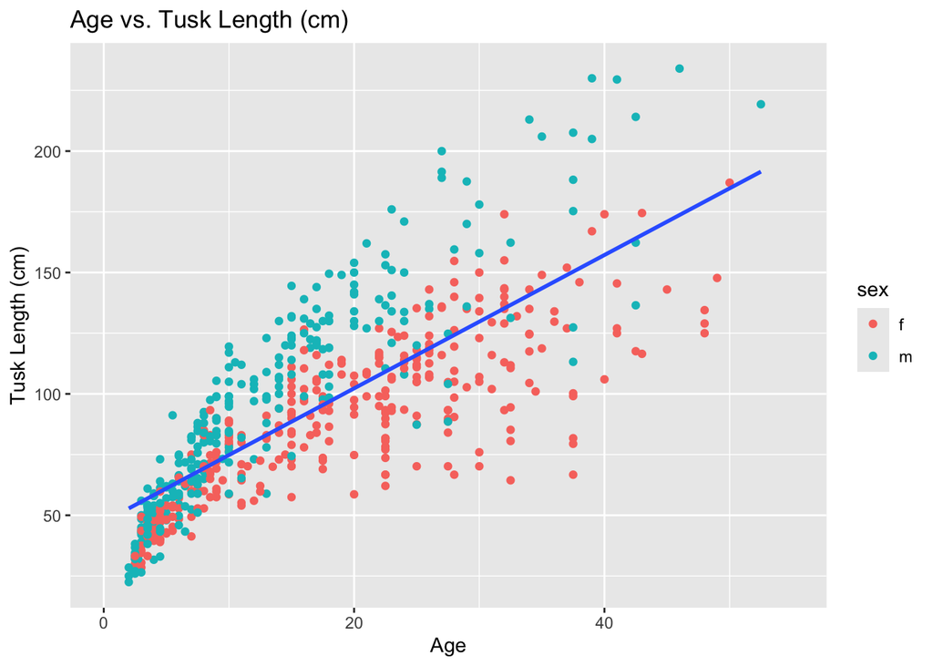

```r
elephants %>%
  ggplot(mapping = aes(x = estimated_age_years, y = tusk_length_in_cm)) +
  geom_point(mapping = aes(color = sex)) +
  geom_smooth(method = lm, se = F, na.rm = T) +
  labs(title = "Age vs. Tusk Length (cm)",
      x = "Age",
      y = "Tusk Length (cm)")
```

Based on the plot, age is a positive predictor of tusk length.

**10. Is shoulder height (independent variable) a positive predictor of tusk length (dependent variable)? Create a plot that shows the relationship between these variables and add a linear model fit line.**

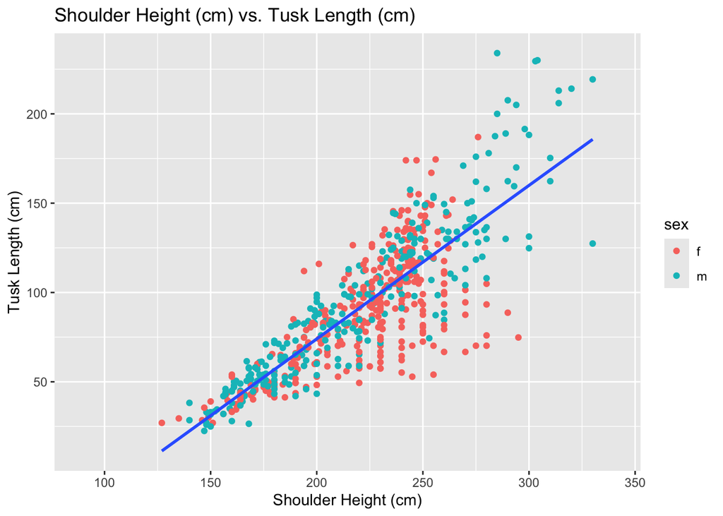

```r
elephants %>%
  ggplot(mapping = aes(x = shoulder_height_in_cm, y = tusk_length_in_cm)) +
  geom_point(mapping = aes(color = sex)) +
  geom_smooth(method = lm, se = F, na.rm = T) +
  labs(title = "Shoulder Height (cm) vs. Tusk Length (cm)",
      x = "Shoulder Height (cm)",
      y = "Tusk Length (cm)")
```

Shoulder height is a positive predictor of tusk length.

**11. The authors argue that because poachers preferentially target elephants with large tusks, this has resulted in a decrease in average tusk length. Is this supported by the data? Show your code and calculations below.**

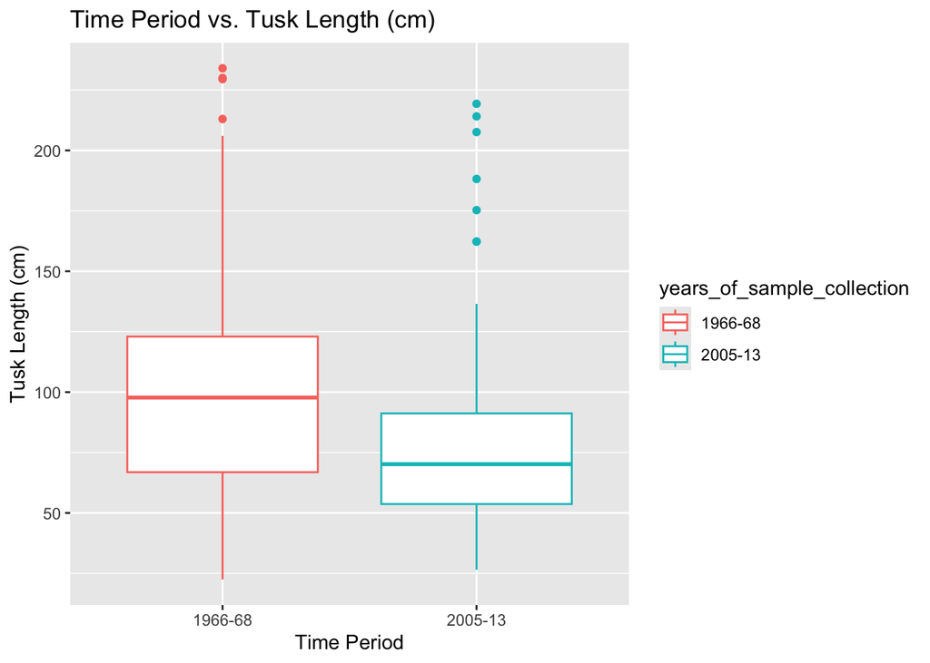

```r
elephants %>%
  ggplot(mapping = aes(x = years_of_sample_collection, y = tusk_length_in_cm)) +
  geom_boxplot(mapping = aes(color = years_of_sample_collection)) +
  labs(title = "Time Period vs. Tusk Length (cm)",
      x = "Time Period",
      y = "Tusk Length (cm)") #for this problem, better to not plot and instead use means/max/min/sd
```

The data does support that because poachers preferentially target elephants with large tusks, this has resulted in a decrease in average tusk length

```r
elephants %>%
    filter(years_of_sample_collection == "1966-68") %>%
  summarize(mean_tusk_length = mean(tusk_length_in_cm, na.rm = T),
            min_tusk_length = min(tusk_length_in_cm, na.rm = T),
            max_tusk_length = max(tusk_length_in_cm, na.rm = T),
            total = n())
```

```
##   mean_tusk_length min_tusk_length max_tusk_length total
## 1         96.90436            22.5             234   605
```

```r
elephants %>%
    filter(years_of_sample_collection == "2005-13") %>%
  summarize(mean_tusk_length = mean(tusk_length_in_cm, na.rm = T),
            min_tusk_length = min(tusk_length_in_cm, na.rm = T),
            max_tusk_length = max(tusk_length_in_cm, na.rm = T),
            total = n())
```

```
##   mean_tusk_length min_tusk_length max_tusk_length total
## 1          77.2056            26.5           219.3   172
```

```r
names(elephants)
```

```
## [1] "years_of_sample_collection" "elephant_id"
## [3] "sex"                        "estimated_age_years"
## [5] "shoulder_height_in_cm"      "tusk_length_in_cm"
## [7] "tusk_circumference_in_cm"
```

**12. Male elephants reach effective sexual maturity at 25 years while females are sexually mature at 12 years. Make a new dataframe that extracts only the males and females at sexual maturity. Then, make a plot that shows the range of tusk length between the two sample periods for these mature elephants.**

```r
elephants_sm <- elephants %>%
  filter((sex == "m" & estimated_age_years >= 25) | (sex == "f" & estimated_age_years >= 12)) #must be isolated from the code chunk with ggplot for ggplot to utilize the new dataframe created, done to help with pipe management (doesn't mix up piping and ggplot functions)
```

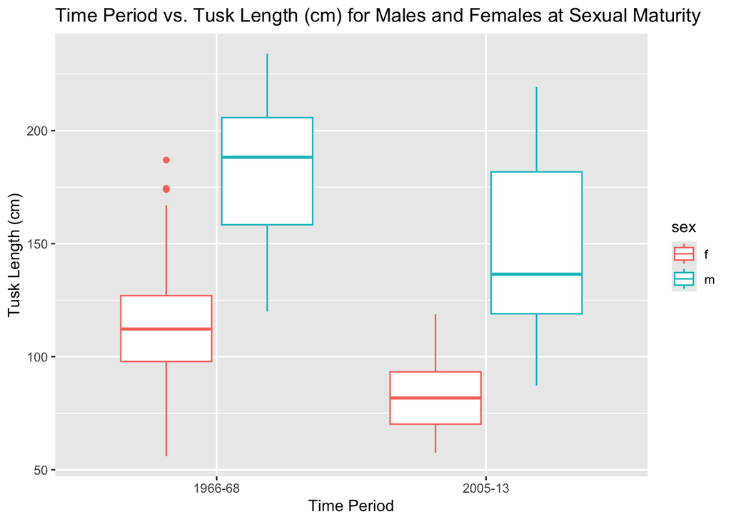

```r
elephants_sm %>%
  ggplot(mapping = aes(x = years_of_sample_collection, y = tusk_length_in_cm)) +
  geom_boxplot(mapping = aes(color = sex)) +
  labs(title = "Time Period vs. Tusk Length (cm) for Males and Females at Sexual Maturity",
      x = "Time Period",
      y = "Tusk Length (cm)") #just present this graph
```

## Submit the Homework

1. Save your work and knit the .rmd file.
2. Open the .html file and “print” it to a .pdf file in Google Chrome (not Safari).
3. Go to the class Canvas page and open Gradescope.
4. Submit your .pdf file to the homework assignment- be sure to assign the pages to the correct questions.
5. Commit and push your work to your repository.